# BIOS 635: Cross-Validation

Kevin Donovan

2/25/2021

# Review

- Homework 4 due on 2/26 at 11PM through GitHub Classroom
- Article Evaluation 1 assigned, due on 3/2 through GitHub Classroom
- Last lecture: nonlinear modeling using splines

# Prediction Error

- Recall prediction error can be calculated a variety of subsets of your data
1. **training error**: average error when predicting outcome on data used to create algorithm
2. **testing error**: average error when predicting outcome on data from that used in training
- Training error poor measure of algorithm’s performance on general sample from population
  - **Biased downward**
  - Need separate and **independent** datasets for testing and training

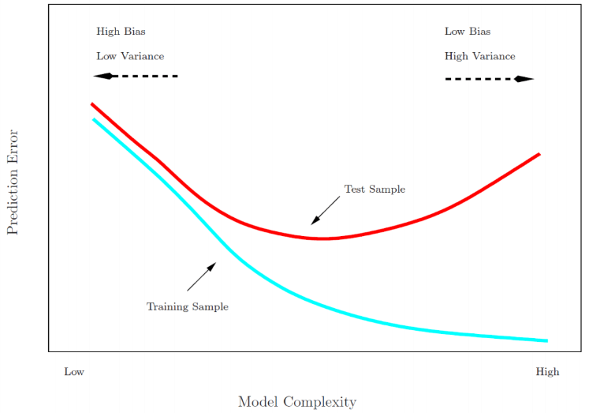

# Training and Testing

1. Training and Tuning

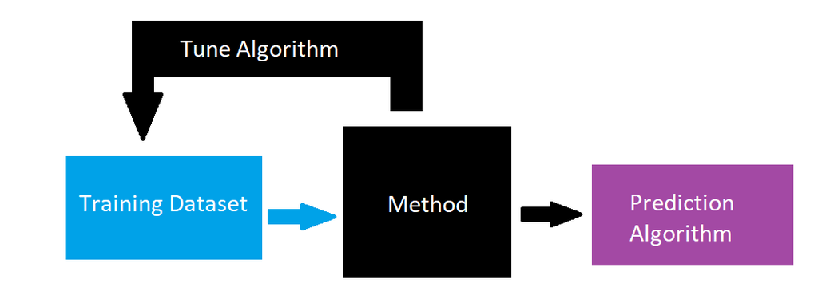

2. Training, Tuning, and Testing

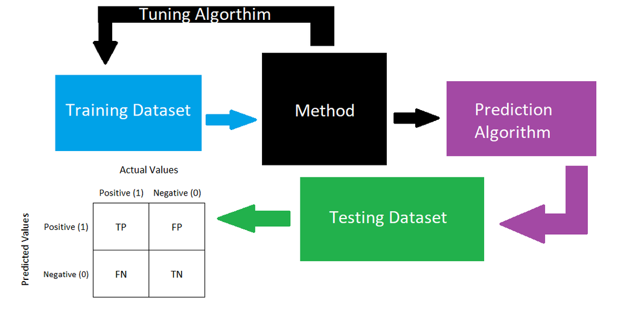

# Testing error

- Various ways have been developed to estimate this testing error:
1. “Correct” training set error to be more generalizable
- **Idea**: $Error=f(MSE)+\lambda*ModelComplexity$ where $\lambda>0$
- Ex. *Mallow’s Cp, AIC, BIC*
2. Use large, independent and separate test set
- Often not available, though best option
3. Generate test set using **hold out**
- Randomly split available data into 2 partitions
- Use one partition for training, other for testing
- Testing = predict outcome on test set, compute prediction error (ex. MSE or misclassification rate)

# Hold out

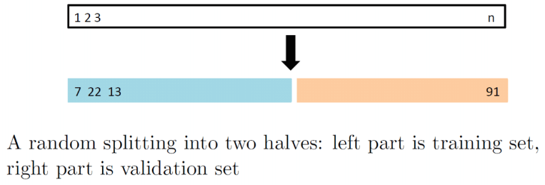

```r
wage_data <- Wage # contained in ISLR package
# Holdout 40% for tesing
tt_indicies <- createDataPartition(y=wage_data$wage, p=0.6, list = FALSE)
wage_data_train <- wage_data[tt_indicies,]
wage_data_test <- wage_data[-tt_indicies,]

# Look at datasets
paged_table(wage_data_train)
```

|  | year | age | maritl | race | education | region | jobclass | health | health_ins | logwage | wage |
| --- | --- | --- | --- | --- | --- | --- | --- | --- | --- | --- | --- |
| 231655 | 2006 | 18 | 1. Never Married | 1. White | 1. < HS Grad | 2. Middle Atlantic | 1. Industrial | 1. <=Good | 2. No | 4.318063 | 75.04315 |
| 161300 | 2003 | 45 | 2. Married | 1. White | 3. Some College | 2. Middle Atlantic | 1. Industrial | 1. <=Good | 1. Yes | 4.875061 | 130.98218 |
| 155159 | 2003 | 43 | 2. Married | 3. Asian | 4. College Grad | 2. Middle Atlantic | 2. Information | 2. >=Very Good | 1. Yes | 5.041393 | 154.68529 |
| 376662 | 2008 | 54 | 2. Married | 1. White | 4. College Grad | 2. Middle Atlantic | 2. Information | 2. >=Very Good | 1. Yes | 4.845098 | 127.11574 |
| 377954 | 2008 | 30 | 1. Never Married | 3. Asian | 3. Some College | 2. Middle Atlantic | 2. Information | 1. <=Good | 1. Yes | 4.716003 | 111.72085 |
| 8690 | 2005 | 35 | 1. Never Married | 1. White | 2. HS Grad | 2. Middle Atlantic | 2. Information | 2. >=Very Good | 1. Yes | 4.494155 | 89.49248 |
| 153561 | 2003 | 39 | 2. Married | 1. White | 4. College Grad | 2. Middle Atlantic | 1. Industrial | 2. >=Very Good | 1. Yes | 4.903090 | 134.70538 |
| 449654 | 2009 | 54 | 2. Married | 1. White | 2. HS Grad | 2. Middle Atlantic | 2. Information | 2. >=Very Good | 1. Yes | 4.903090 | 134.70538 |
| 160191 | 2003 | 37 | 1. Never Married | 3. Asian | 4. College Grad | 2. Middle Atlantic | 1. Industrial | 2. >=Very Good | 2. No | 4.414973 | 82.67964 |
| 230312 | 2006 | 50 | 2. Married | 1. White | 5. Advanced Degree | 2. Middle Atlantic | 2. Information | 2. >=Very Good | 2. No | 5.360552 | 212.84235 |

[output cut: 1792 more lines]

```r
paged_table(wage_data_test)
```

|  | year | age | maritl | race | education | region | jobclass | health | health_ins | logwage | wage |
| --- | --- | --- | --- | --- | --- | --- | --- | --- | --- | --- | --- |
| 86582 | 2004 | 24 | 1. Never Married | 1. White | 4. College Grad | 2. Middle Atlantic | 2. Information | 2. >=Very Good | 2. No | 4.255273 | 70.47602 |
| 11443 | 2005 | 50 | 4. Divorced | 1. White | 2. HS Grad | 2. Middle Atlantic | 2. Information | 1. <=Good | 1. Yes | 4.318063 | 75.04315 |
| 450601 | 2009 | 44 | 2. Married | 4. Other | 3. Some College | 2. Middle Atlantic | 1. Industrial | 2. >=Very Good | 1. Yes | 5.133021 | 169.52854 |
| 228963 | 2006 | 41 | 1. Never Married | 2. Black | 3. Some College | 2. Middle Atlantic | 2. Information | 2. >=Very Good | 1. Yes | 4.778151 | 118.88436 |
| 81404 | 2004 | 52 | 2. Married | 1. White | 2. HS Grad | 2. Middle Atlantic | 2. Information | 2. >=Very Good | 1. Yes | 4.857332 | 128.68049 |
| 302778 | 2007 | 45 | 4. Divorced | 1. White | 3. Some College | 2. Middle Atlantic | 2. Information | 1. <=Good | 1. Yes | 4.763428 | 117.14682 |
| 305706 | 2007 | 34 | 2. Married | 1. White | 2. HS Grad | 2. Middle Atlantic | 1. Industrial | 2. >=Very Good | 2. No | 4.397940 | 81.28325 |
| 447660 | 2009 | 51 | 2. Married | 1. White | 3. Some College | 2. Middle Atlantic | 1. Industrial | 2. >=Very Good | 1. Yes | 4.505150 | 90.48191 |
| 158226 | 2003 | 38 | 2. Married | 3. Asian | 4. College Grad | 2. Middle Atlantic | 2. Information | 2. >=Very Good | 2. No | 5.301030 | 200.54326 |
| 11141 | 2005 | 40 | 4. Divorced | 1. White | 2. HS Grad | 2. Middle Atlantic | 2. Information | 2. >=Very Good | 2. No | 3.920123 | 50.40666 |

[output cut: 1188 more lines]

# Training and testing

- Consider fitting nonlinear polynomial to wage data
- Using training error vs. testing error to choose spline order

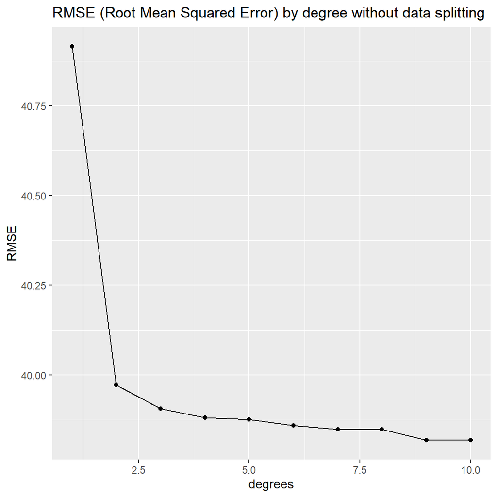

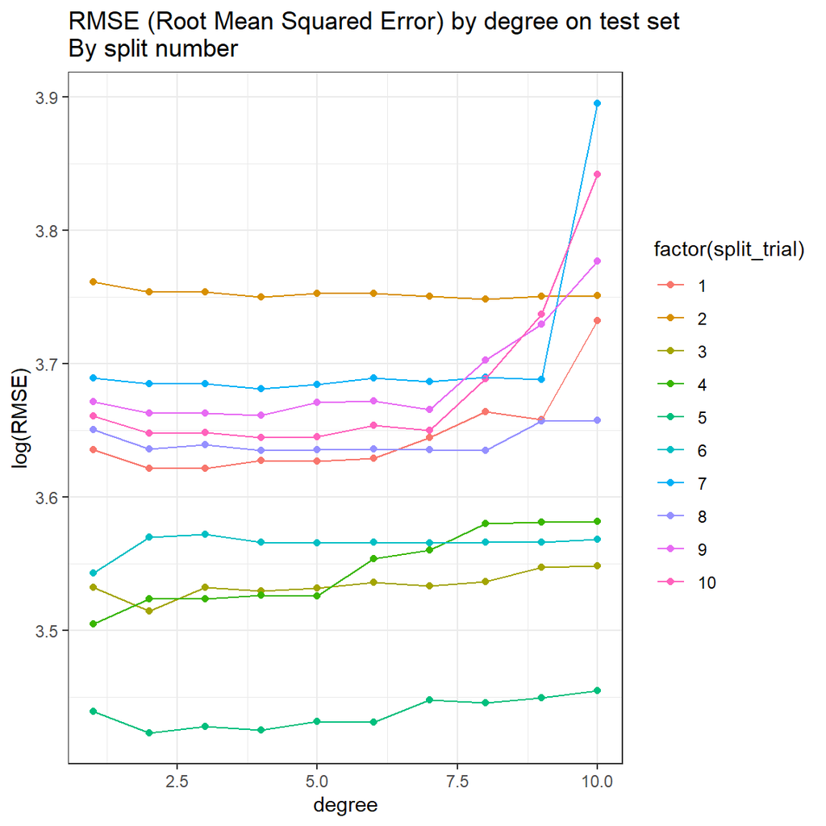

# Drawbacks of holdout

- Test set error can be highly dependent on split
  - Thus **highly variable**
  - Especially for small dataset or **small group sizes**
- Only subset of data used to train algorithm
  - May result in poorer algorithm
  - $\rightarrow$ may **overestimate** test error
- Can we **aggregate results over multiple test sets?**

# K-fold cross validation

- **Widely used** approach for estimating test error
- **Idea**: Still use entire data for training but evaluate **average** performance by aggregating over multiple test sets
  - Test sets still must be **independent**
  - Example: 5-fold CV

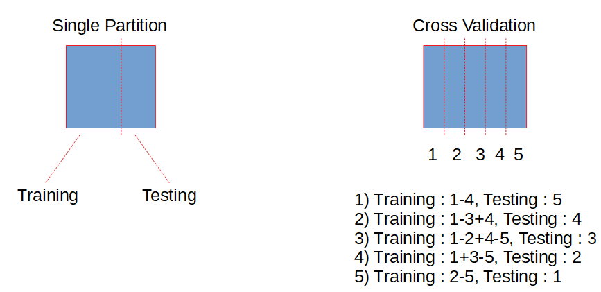

# K-fold cross validation

- Denote $K$ folds by $C_1, C_2, \ldots, C_K$, each with $n_k$ observations
- For a given fold $l$:
  1. Train algorithm on data in other folds: $\{C_k\}$ s.t. $k\neq l$
  2. Test by computing predicted values for data in $C_l$ **only**
  3. Repeat for each fold $l=1, \ldots, K$, average error (ex. $MSE_l$)
- K fold CV error rate

- $K=n$ yields $n-fold$ or *leave-one out cross-validation*
- $CV_{(K)}$ is accurate measure of generalized error rate for algorithm trained on whole sample

# K-fold CV in R

```r
# 5 fold CV partitions
cv_folds <- createFolds(y=wage_data_subset$wage, k=5)
# Can see whose in fold 1
cv_folds$Fold1
```

```
##  [1]   1  13  20  25  27  28  34  39  46  48  56  62  68  69  72  76  79  86  87
## [20]  88  97 101 102 104 109 111 112 116 125 129 130 148 150 155 161 163 164 167
## [39] 169 179 185 188 193 215 217 229 233 234 235 246 251 264 272 277 279 282 293
## [58] 298 300 304 309 311 324 325 326 337 344 348 352 356 357 362 373 374 377 378
## [77] 380 383 384 386 398
```

```r
# Look at dataset for fold 1
wage_data_fold_1 <- wage_data_subset[cv_folds$Fold1,]
paged_table(wage_data_fold_1)
```

|  | year | age | maritl | race | education | region | jobclass | health | health_ins | logwage | wage |
| --- | --- | --- | --- | --- | --- | --- | --- | --- | --- | --- | --- |
| 377324 | 2008 | 53 | 2. Married | 1. White | 2. HS Grad | 2. Middle Atlantic | 1. Industrial | 2. >=Very Good | 2. No | 4.681241 | 107.90392 |
| 307313 | 2007 | 51 | 2. Married | 1. White | 2. HS Grad | 2. Middle Atlantic | 1. Industrial | 1. <=Good | 1. Yes | 4.892095 | 133.23235 |
| 11522 | 2005 | 44 | 2. Married | 2. Black | 3. Some College | 2. Middle Atlantic | 2. Information | 1. <=Good | 1. Yes | 4.447158 | 85.38394 |
| 82172 | 2004 | 54 | 2. Married | 2. Black | 2. HS Grad | 2. Middle Atlantic | 2. Information | 1. <=Good | 1. Yes | 4.698970 | 109.83399 |
| 156397 | 2003 | 30 | 2. Married | 1. White | 5. Advanced Degree | 2. Middle Atlantic | 1. Industrial | 2. >=Very Good | 1. Yes | 4.556303 | 95.23071 |
| 231714 | 2006 | 46 | 2. Married | 1. White | 3. Some College | 2. Middle Atlantic | 2. Information | 2. >=Very Good | 1. Yes | 4.939325 | 139.67587 |
| 231998 | 2006 | 34 | 2. Married | 1. White | 2. HS Grad | 2. Middle Atlantic | 1. Industrial | 1. <=Good | 2. No | 4.041393 | 56.90554 |
| 230878 | 2006 | 45 | 2. Married | 1. White | 2. HS Grad | 2. Middle Atlantic | 1. Industrial | 2. >=Very Good | 2. No | 4.619093 | 101.40205 |
| 160071 | 2003 | 62 | 2. Married | 1. White | 4. College Grad | 2. Middle Atlantic | 1. Industrial | 2. >=Very Good | 1. Yes | 4.845098 | 127.11574 |
| 452617 | 2009 | 24 | 2. Married | 1. White | 1. < HS Grad | 2. Middle Atlantic | 1. Industrial | 2. >=Very Good | 2. No | 5.000000 | 148.41316 |

[output cut: 71 more lines]

# K-fold CV analysis

- Let’s look back at the nonlinear fitting example from before. Instead of using a holdout testing method, we use 5-fold CV

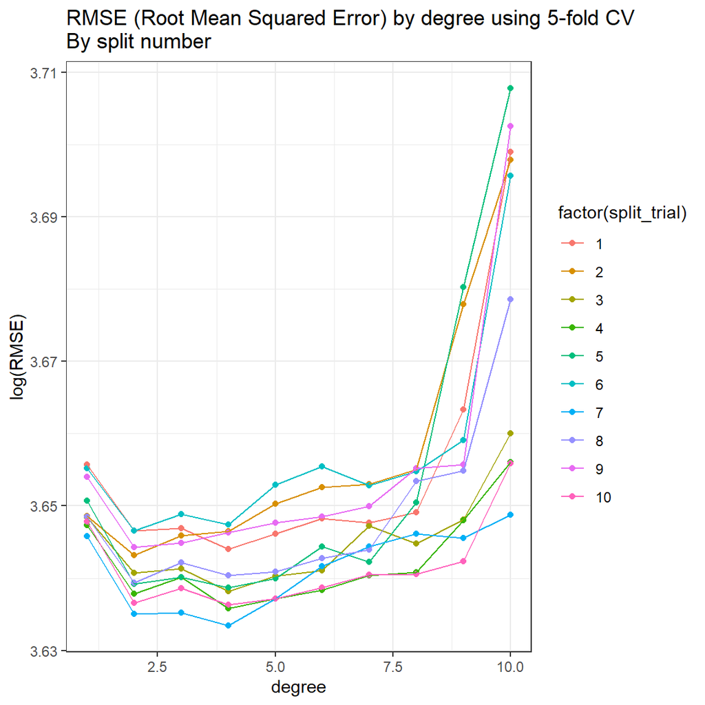

```r
# Fit model for each degree considered, compute RMSE (on training in this ex.)
poly_reg_fit <- list()
predict_wages <- list()
residuals_wages <- list()
rmse_poly_reg <- list()
mae_poly_reg <- list()
error_rates_degrees <- list()

counter <- 1
trials <- 10 # Look at 10 different 60:40 splits

for(j in 1:trials){
  set.seed(j) # Set seed to get different splits

  tt_indicies <- createFolds(y=wage_data_subset$wage, k=5)

    for(i in 1:length(degrees)){
      for(f in 1:length(tt_indicies)){
        wage_data_train <- wage_data_subset[-tt_indicies[[f]],]
        wage_data_test <- wage_data_subset[tt_indicies[[f]],]

        poly_reg_fit[[f]] <- lm(wage~poly(age, degrees[i]),
                         data=wage_data_train)

        predict_wages[[f]] <- predict(poly_reg_fit[[f]], newdata = wage_data_test)
        residuals_wages[[f]] <- wage_data_test$wage-predict_wages[[f]]
        rmse_poly_reg[[f]] <- sqrt(mean(residuals_wages[[f]]^2))
        mae_poly_reg[[f]] <- mean(abs(residuals_wages[[f]]))
      }

        # Save in data frame
        error_rates_degrees[[counter]] <-
          data.frame("RMSE"=mean(unlist(rmse_poly_reg)),
                     "MAE"=mean(unlist(mae_poly_reg)),
                     "degree"=degrees[i],
                     "split_trial"=j)
        counter <- counter+1
    }
}

  # Bind all degree-specific results together into single data frame/table
  error_rates_degrees_df <- do.call("rbind", error_rates_degrees)

  # Plot results as function of degree
  ggplot(data=error_rates_degrees_df,
         mapping=aes(x=degree, y=log(RMSE), color=factor(split_trial)))+
    geom_point()+
    geom_line()+
    labs(title="RMSE (Root Mean Squared Error) by degree using 5-fold CV\nBy split number")+
    theme_bw()
```

# Choosing K: bias-variance tradeoff

- **Recall**: Holdout method uses only portion of data for training
  - $\rightarrow$ test/validation performance **overestimate**
  - $\rightarrow$ more folds $\rightarrow$ more data in training folds $\rightarrow$ better algorithm $\rightarrow$ lower mean error
  - $\rightarrow$ LOOCV least biased estimate of test error
- Compared to hold out, each training set in K-fold contains $\frac{(k-1)n}{k}$ obs
  - Generally more then in holdout $\rightarrow$ less biased estimate

# Choosing K: bias-variance tradeoff

- **Recall**: Test set performance from holdout method can vary a lot depending on split
  - $\rightarrow$ not a **precise** measure of test set error
- Can decrease variance using aggregate method like K-fold CV
  - With LOOCV, averaging performance of $n$ trained algorithms
  - Testing folds differ, but training sets have almost identical set of observations
  - $\rightarrow$ test fold performances **highly correlated**
  - Using K-fold CV with $K<n$ decrease training set overlap $\rightarrow$ less correlated
  - $\rightarrow$ variance of K-fold CV < LOOCV
- This creates a **bias-variance** tradeoff when choosing K
  - K=5 or 10 generally chosen (based on simulation studies)

# CV for classification

- Same process as before, divide data into $K$ partitions $C_1, \ldots, C_K$
- Choose error/accuracy rate of interest
  - E.g. sensitivity, specificity, classification error, etc.
- For classification error
  - Compute CV error

$$CV_K=\sum_{k=1}^{K}\frac{n_k}{n}\text{Error}_k=\frac{1}{K}\sum_{k=1}^{K}\text{Error}_k$$

where $\text{Error}_k=\sum_{i \in C_k}I(y_i \neq \hat{y_i})/n_k$

- Can we estimate the **variability** of this estimate?
  - Commonly used estimate of standard error:

$$\hat{\text{SE}}(\text{CV}_K)=\sqrt{\sum_{k=1}^{K}(\text{Error}_k-\overline{\text{Error}_k})^2/(K-1)}$$

- While useful, not accurate (**Why?**)
- Also can be used in continuous prediction CV (using MSE for example)

# CV for classification

In R: heart disease prediction with LDA (see lecture 6)

```r
heart_data <- read_csv(file="../data/heart_disease/Correct_Dataset.csv") %>%
  mutate(heart_disease =
           relevel(factor(ifelse(Target>0, "Yes", "No")),
                   ref = "No"))

# Create lists to hold results
lda_fit <- list()
estimted_probs <- list()
accuracy_rates <- list()

# Create 5 folds
tt_indicies <- createFolds(y=heart_data$heart_disease, k=5)

# Run LDA for each fold, store results
for(f in 1:length(tt_indicies)){
  heart_data_train <- heart_data[-tt_indicies[[f]],]
  heart_data_test <- heart_data[tt_indicies[[f]],]

  lda_fit[[f]] <- train(heart_disease~Age+Sex+Chest_Pain+Resting_Blood_Pressure+
                               Colestrol+MAX_Heart_Rate+Exercised_Induced_Angina,
                             data = heart_data_train, method = "lda")

  estimted_probs[[f]] <- predict(lda_fit[[f]], newdata=heart_data_test, type = "prob")$Yes
  pred_heart_disease <-
    relevel(factor(ifelse(estimted_probs[[f]]>0.5,
                          "Yes", "No")), ref = "No")
  # Get accuracy rates from output
  accuracy_rates[[f]] <-
    c(confusionMatrix(pred_heart_disease,
                reference = heart_data_test$heart_disease,
                positive = "Yes")$byClass,
      confusionMatrix(pred_heart_disease,
                reference = heart_data_test$heart_disease,
                positive = "Yes")$overall,
      "fold"=f)
}

accuracy_df <- data.frame(do.call("rbind", accuracy_rates))

# Compute mean and SE for each measure to get CV mean/SE
CV_mean <- accuracy_df %>%
  select(Sensitivity, Specificity, `Pos.Pred.Value`, `Neg.Pred.Value`, Accuracy) %>%
  apply(MARGIN = 2, FUN=mean)

CV_se <- accuracy_df %>%
  select(Sensitivity, Specificity, `Pos.Pred.Value`, `Neg.Pred.Value`, Accuracy) %>%
  apply(MARGIN = 2, FUN=sd)

CV_mean
```

```
##    Sensitivity    Specificity Pos.Pred.Value Neg.Pred.Value       Accuracy
##      0.7116402      0.8482955      0.8022736      0.7766796      0.7855738
```

```r
CV_se
```

```
##    Sensitivity    Specificity Pos.Pred.Value Neg.Pred.Value       Accuracy
##     0.05530303     0.07066323     0.08905437     0.03575939     0.05204986
```

# CV with tuning

- **Recall**: Often when training a prediction algorithm, need to select **tuning parameters**
  - Ex. # of neighbors with KNN, number of features with regression, degree in splines, etc.
  - Where is tuning implemented in CV?
- Example: Consider set of 5000 predictors and 50 samples of data
  - 1. Starting with the 5000 predictors and full data, **first** find 100 predictors with largest correlation with outcome
  - 2. Then train and test an algorithm with only these 100 predictors, using logistic regression as an example
- How do we estimate the algorithm’s test set performance without bias?
- Can we only apply CV in step 2, after the predictors have been chosen using the full data?

# NO

- Why?
  - This selection of parameters greatly impacts the algorithm’s performance and thus is a form of tuning
  - Tuning needs to be done within the training framework, otherwise you are training and testing on the same dataset
  - Thus, need to do step 1 within your CV scheme

# Wrong way: visual

- Only doing step 2 inside CV process

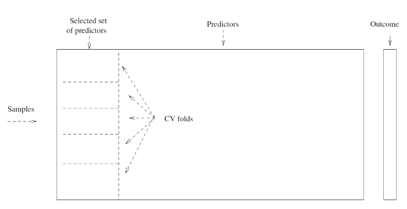

# Right way: visual

- Doing both steps 1 and 2 within CV process

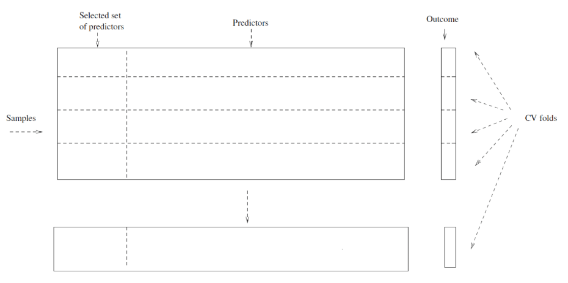

# Song of the session

[Green Eggs and Ham by Princess Nokia](https://www.youtube.com/watch?v=ZZH4p5DZulo)

[figure not shown]